# I. butschlii.

Enero 2022.

## Generalidades.

- Nombrada por Prowazek en 1912.
- Ameba intestinal, parasitaria y no patógena.
- Transmisión fecal-oral.

## Taxonomía.

1. Protozoa.
2. Neozoa.
3. Amoebozoa.
4. Entamoebidea.
5. Euamoebida.
6. Iodamoeba.
7. *I. butschlii*.

## Morfología.

- Trofozoíto.
- Quiste.

## Morfología (trofozoíto).

- 12-15 \(\mu\)m.
- Forma irregular.
- Mononucleado.
- Núcleo con cariosoma central.
- Pequeña vacuola de glucógeno.
- Citoplasma granular, grueso y vacuolado.
  - Puede contener bacterias o levaduras.
- Se desplaza mediante pseudópodos cortos.

## Morfología (quiste).

- 10-12 \(\mu\)m.
- Ovoide, esférico o piriforme.
- Mononucleado.
- Núcleo con cariosoma excéntrico.
- Gran vacuola de glucógeno.
- Citoplasma yodofílico.

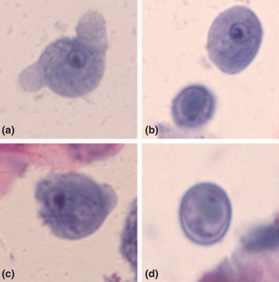

*I. butschlii*. 1 000x. Aceite de inmersión.

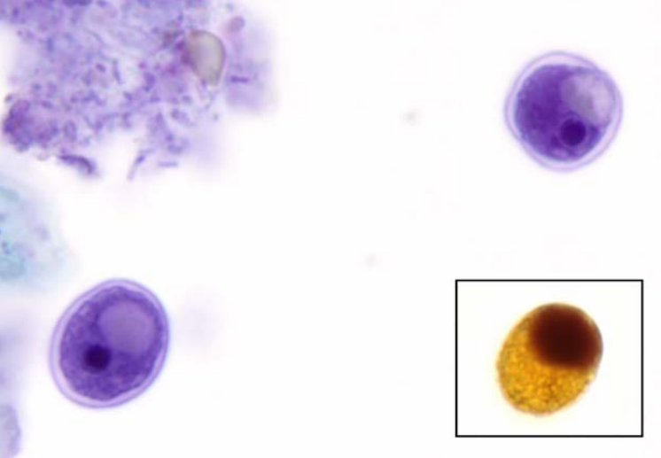

## Epidemiología.

- Distribución mundial.
  - México, Sudamérica.
  - África, Sudáfrica.
  - Oriente Medio e India.
- Incidencia:
  - \(<\) áreas urbanas.
  - \(>\) zonas rurales.
- La ameba más frecuente en cerdos.
- Prevalencia en humanos 4-8%.

## Ciclo de vida.

1. Ingesta de quistes maduros.
2. Desenquistamiento (1 quiste = 2 trofozoítos).
3. Migración al intestino grueso (fosfolipasa).
4. Multiplicación por fisión binaria.
5. Se alimentan de bacterias y hongos.
6. Enquistamiento.
7. Expulsión en heces.

## Aspectos clínicos.

- Colonización no invasiva.
- No causa síntomas de enfermedad.
- Puede producir amebiasis en pacientes inmunocomprometidos.

## Sintomatología (de producirse).

- Anorexia.
- Colitis.
- Diarrea.
- Dispepsia.
- Insomnio.

## Diagnóstico.

- Métodos coproparasitoscópicos.
  - Quistes en heces formadas.
  - Trofozoítos en heces diarréicas.

## Diagnóstico diferencial.

- *Endolimax nana*.
- *Entamoeba histolytica*.

## Tratamiento.

- Agentes antiparasitarios.
  - Metronidazol.
  - Tinidazol.

## Prognosis.

- El tratamiento adecuado cura la amebiasis en semanas.
- Puede ocurrir reinfección.

## Caso clínico.

- Hombre homosexual de 35 años, quien dio negativo a HIV, presenta diarrea acuosa de 5 semanas. El paciente fue atendido en una clínica médica genitourinaria, en donde se le dio un diagnóstico inicial de criptosporidiosis. No se le especificó tratamiento y los síntomas disminuyeron por sí mismos, aunque el paciente continuó sintiéndose mal y perdió 3 kg de peso. La diarrea reapareció en una ocasión y lo hizo acompañada de sangre.
- Estudios de laboratorio demostraron resultados normales en hemoglobina, recuento de glóbulos blancos y frotis de sangre, así como un perfil bioquímico normal. No obstante, el examen parasitológico en heces mostró un gran número de quistes de *Iodamoeba butschlii*. La identificación fue confirmada por el Departamento de Parasitología Clínica del Hospital de Enfermedades Tropicales, en Londres, Inglaterra.

## Caso clínico (cont.).

- Al paciente se le suministraron 800 mg de metronidazol cada 8 horas por 1 semana, desapareciendo los síntomas al cabo de 4-5 días. Luego de ese tiempo, se repiten los exámenes coproparasitoscópicos, no encontrándose parásitos.
- Después de 1 mes el paciente fue reportado completamente sano.

## Profilaxis.

- Evitar el consumo de agua y alimentos contaminados.
- Lavar y cocinar bien los alimentos.
- Técnica de lavado de manos.
- Buenas prácticas de higiene.

## Bibliografía.

1. Apurba Sankar Sastry, Sandhya Baht K. (2014). *Essentials of medical parasitology*. Jaypee Brothers Medical Publishers (P) LTD.

2. Arava, S., Sharma, A., Iyer, V.K. & Mathur, S.R. (2009). Iodamoeba butschlii in a routine cervical smear. *Cytopathology*, *21*(5), 342–343. https://doi.org/10.1111/j.1365-2303.2009.00717.x

3. Centers for Disease Control and Prevention. (2019). *CDC - DPDx - Intestinal (Non-Pathogenic) Amebae*. https://www.cdc.gov/dpdx/intestinalamebae/index.html

4. Cohen, J. (1996). Metronidazole to clear intestinal parasites. *The Lancet*, *348*(9022), 273. https://doi.org/10.1016/S0140-6736(05)65588-2

5. Pérez-Molina, J.A. et al. (2010). Tratamiento de las enfermedades causadas por parásitos. *Enfermedades Infecciosas y Microbiología Clínica*, *28*(1), 44–59. https://doi.org/10.1016/j.eimc.2009.11.003

6. Schuetz, A.N., Pritt, B.S. & Schreiner, A.M. (2013). Iodamoeba butschlii in an anal pap test confirmed by iodine stain. *Diagnostic Cytopathology*, *42*(9), 775–777. https://doi.org/10.1002/dc.23042